# When Physics lives on the Interface: Surface Manifolds PDEs

TCM Team Meeting, April 2026

Thomas Sobre, Louis Libat, Can Selçuk, Eric Chénier, Vincent Le Chenadec

Multiscale Modeling and Simulation Laboratory (MSME), CNRS UMR 8208, Gustave Eiffel University, France

2026-04-10

# Motivation

## When physics lives on the interface

- Some physics does **not** live in the volume
- It lives on an **interface**: membranes, films, droplets, bubbles
- A surface PDE is the natural model when the layer is **thin** and **active**
- Geometry matters: **tangency, curvature, transport on the interface**

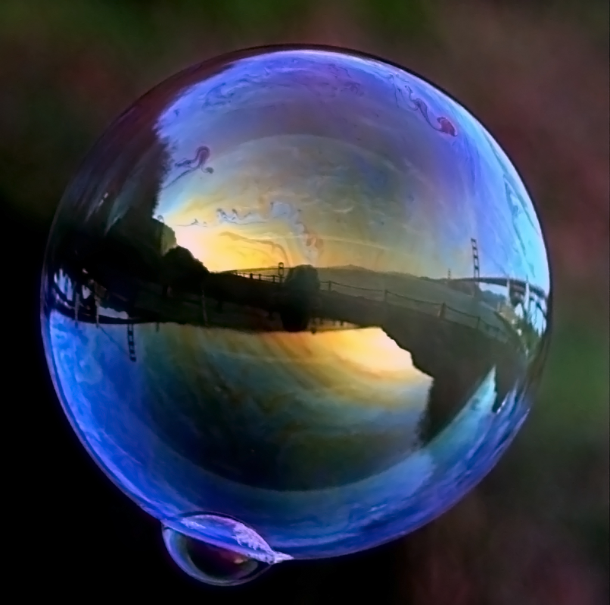

## Why solve on the surface?

- The unknown is **confined to the interface itself**
- We avoid resolving an artificial **thin bulk layer**
- Diffusion, advection, and reaction follow the **geometry of the manifold**
- This is the right language for **surfactants, membranes, interfacial chemistry**
- In multiphase flows, the interface is often where the **interesting physics** happens

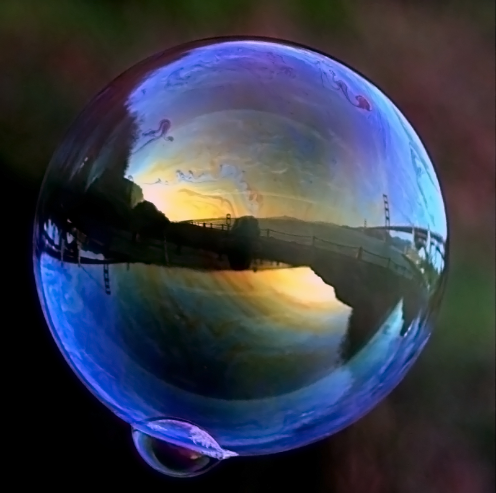

Thin active layer $\Rightarrow$ intrinsic surface model

## The point of view for this talk

- I will stay at the level of **surface PDEs on a given mesh**
- The new ingredient is simple:

Solve the PDE **on the interface itself**, not in the surrounding bulk.

- Then a natural question appears:

How do we build **differential operators on a curved discrete surface**?

## Roadmap

1. What is a surface PDE?
2. What changes compared with a bulk PDE?
3. The DDG / DEC point of view
4. From geometry to discrete operators
5. Solving diffusion / transport / reaction on surfaces
6. Moving surfaces and space-time ideas
7. What this gives us for multiphase-flow applications

# Surface PDEs: the continuous picture

## A surface is the domain

Let $\Gamma \subset \mathbb R^3$ be a smooth surface.

A scalar surface field is

$$u : \Gamma \to \mathbb R.$$

Examples:

- surfactant concentration
- membrane potential
- surface temperature
- interfacial reaction product density

**$\Gamma$ is the computational domain**

This is not $\Omega^-$ or $\Omega^+$. The interface is not a boundary condition. The interface is the domain.

## The basic differential operators

On a surface, we replace standard Euclidean operators by their **tangential** counterparts.

- tangential gradient

$$\nabla_\Gamma u = \mathbf P\nabla u
\qquad
\mathbf P = \mathbf I - \mathbf n\otimes \mathbf n$$

- surface divergence

$$\nabla_\Gamma\cdot \mathbf w$$

- Laplace–Beltrami operator

$$\Delta_\Gamma u = \nabla_\Gamma \cdot \nabla_\Gamma u$$

The normal direction is removed: everything lives in the **tangent plane**.

## Canonical model problems

A few model equations come back again and again.

**Surface diffusion**

$$\partial_t u - D\Delta_\Gamma u = f$$

**Surface advection–diffusion**

$$\partial_t u + \nabla_\Gamma \cdot (u\mathbf w_\tau) - D\Delta_\Gamma u = f$$

**Surface reaction–diffusion**

$$\partial_t u - D\Delta_\Gamma u = R(u)$$

These are the surface analogues of familiar bulk PDEs.

## What changes compared with a bulk PDE?

**Same ideas**

- conservation
- diffusion
- transport
- reaction
- boundary / initial conditions

**New ingredients**

- the domain is curved
- only tangential directions are allowed
- metric information matters
- curvature may enter the model
- the mesh is a surface mesh, not a volume mesh

**For moving interfaces**

- the domain itself evolves
- the material derivative is now on $\Gamma(t)$
- geometry and physics are coupled
- one must transport quantities on a changing manifold

## A transport theorem on the surface

For a moving surface $\Gamma(t)$ with normal velocity $V_n$ and tangential velocity $\mathbf w_\tau$,

$$\frac{d}{dt}\int_{\Gamma(t)} udS
= \int_{\Gamma(t)} \big(
\partial_t^\bullet u
+u\nabla_\Gamma\cdot \mathbf w
\big)dS$$

where $\partial_t^\bullet u$ is the material derivative on the moving surface.

This is the surface analogue of Reynolds’ transport theorem.

It is the right starting point for conservative formulations on evolving fronts.

## A familiar multiphase example: surfactant transport

On an interface $\Gamma(t)$,

$$\partial_t^\bullet c + c\nabla_\Gamma\cdot \mathbf w
+ \nabla_\Gamma\cdot(c\mathbf w_\tau)
- D_s\Delta_\Gamma c = R(c)$$

Interpretation:

- $c$ is carried by the moving interface
- it can also be advected tangentially
- it diffuses along the surface
- it may react or exchange mass with the bulk

For multiphase flows, this is often the most natural surface PDE.

# Why DDG and DEC?

## A practical question

If the surface is given by a triangulated mesh,

how do we discretize $\nabla_\Gamma$, $\nabla_\Gamma\cdot$, and $\Delta_\Gamma$ without flattening the geometry or introducing coordinates everywhere?

We want a method that is:

- intrinsic
- conservative
- geometry-aware
- compatible with the mesh topology

## DDG: discrete differential geometry

DDG is the viewpoint:

- start from the **geometric structure** of the continuous problem
- preserve the geometric identities as much as possible
- use the mesh as a discrete geometric object, not only as interpolation support

Typical quantities are:

- normals
- tangent planes
- curvature
- area / length / dual areas
- intrinsic derivatives on the mesh

The message is simple:

geometry is not decoration; geometry is part of the operator.

## DEC: discrete exterior calculus

DEC is one concrete framework inside DDG.

Main idea:

- replace smooth differential forms by **cochains** on the mesh
- replace the exterior derivative by **incidence matrices**
- encode the metric through a **Hodge star**

This gives a discrete analogue of the de Rham complex:
$$0 \longrightarrow \Lambda^0
\xrightarrow{d}
\Lambda^1
\xrightarrow{d}
\Lambda^2
\longrightarrow 0$$

On a triangulated surface:

- 0-forms live on **vertices**
- 1-forms live on **edges**
- 2-forms live on **faces**

## Why this is attractive for CFD people

Because it mirrors ideas you already trust:

- incidence matrices are like signed connectivity in FV/FEM
- exact identities come from topology, not from quadrature accidents
- metric terms are separated from connectivity terms
- conservation laws stay visible
- the method is naturally adapted to curved triangulated fronts

DEC is not magic.

It is a clean way to separate:

**topology** from **geometry**

## The two ingredients: topology and metric

### Topology

Encoded by the discrete exterior derivative.

For a surface mesh:

- $d_0$: vertex $\to$ edge incidence
- $d_1$: edge $\to$ face incidence

and always
$$d_1 d_0 = 0$$
which is the discrete version of
$$\nabla \times \nabla = 0,
\qquad
\nabla \cdot \nabla \times = 0.$$

### Metric

Encoded by Hodge stars:

- primal $k$-cochains to dual $(2-k)$-cochains
- lengths, areas, dual areas, local metric information

## What is a cochain, concretely?

For this talk, think of it very simply.

- a **0-cochain** stores scalar values at vertices
- a **1-cochain** stores integrated tangential information along edges
- a **2-cochain** stores integrated densities over faces

So DEC does not start from nodal interpolation formulas. It starts from **integrated geometric quantities** attached to mesh entities.

This is one reason conservation and exact sequence properties come out naturally.

## The Laplace–Beltrami operator in DEC

For a scalar field on vertices,
$$\Delta_\Gamma u
\quad \leadsto \quad
\star_0^{-1} d_0^\top \star_1 d_0 , u$$

Read from right to left:

- take a discrete gradient with $d_0$
- convert it through metric information with $\star_1$
- take a discrete divergence with $d_0^\top$
- scale back with $\star_0^{-1}$

## One important message

DEC gives us more than one operator. It gives us a **compatible operator chain**.

That matters because surface PDEs are rarely only “one Laplacian.” We often need:

- gradients
- divergences
- Laplacians
- fluxes
- transport terms
- curvature-related quantities

A compatible framework is extremely helpful once the models get richer.

# From surface mesh to discrete operators

## Discrete surface mesh

We assume a front mesh made of vertices, edges, and triangular faces.

From it we compute:

- face areas
- edge lengths
- unit normals
- vertex dual areas
- cotangent or DEC metric weights
- local tangent frames if needed

This geometric preprocessing is the bridge between the front representation and the PDE solver.

## The solver pipeline

A useful way to think about the code is:

mesh / geometry $\rightarrow$ DEC operators $\rightarrow$ assembly $\rightarrow$ solve

More explicitly:

1. build mesh topology
2. compute geometric measures
3. build $d_0$, $d_1$, Hodge stars, Laplace–Beltrami, transport operators
4. assemble the linear or nonlinear system
5. solve and postprocess on the surface

That is the same spirit as in bulk CFD codes, but now the domain is the manifold.

## Surface diffusion: semi-discrete form

For
$$\partial_t u - D\Delta_\Gamma u = f,$$
a typical DEC semi-discretization is
$$M \frac{u^{n+1}-u^n}{\Delta t} + D K u^{n+1} = b^{n+1}$$
with
$$M = \star_0,
\qquad
K = d_0^\top \star_1 d_0.$$

This looks very familiar:

- a mass matrix
- a stiffness matrix
- an implicit time step if desired

The new part is where these matrices come from.

## Surface transport: what is delicate?

Diffusion is already geometric. Transport is even more delicate because we need:

- a tangential velocity field
- consistent fluxes along the surface
- stability for sharp gradients
- conservative treatment on curved triangles

Depending on the formulation, we may use:

- DEC-compatible flux operators
- vertex/edge/face reconstructions
- IMEX treatment for advection–diffusion problems

For moving surfaces, transport is the first place where geometric consistency becomes critical.

## A minimal example: heat equation on the sphere

A good first benchmark is the surface heat equation on the unit sphere.

Why?

- smooth geometry
- known Laplace–Beltrami eigenfunctions
- simple exact solutions
- easy convergence studies

For instance, if $Y_\ell^m$ is a spherical harmonic,
$$u(t,\mathbf x) = e^{-\ell(\ell+1)t} Y_\ell^m(\mathbf x)$$
solves the heat equation on the unit sphere.

This gives a clean verification case for a surface diffusion solver.

## Open surfaces and boundary conditions

Surface PDEs are not limited to closed surfaces.

On an open surface, we can prescribe:

- Dirichlet data on the boundary curve
- Neumann-type tangential fluxes
- Robin conditions

So conceptually, solving a PDE on a manifold with boundary is not so different from solving on a volume domain with boundary.

The difference is that both the domain and its boundary are lower-dimensional geometric objects.

# A simple DDG / DEC narrative

## What DDG buys us

For a CFD audience, the payoff is this:

- we work directly on the triangulated interface
- operators are intrinsic to the surface
- geometry enters in a controlled way
- conservation and compatibility are built into the formulation
- the same language extends from static to moving surfaces

This is why DDG/DEC is a natural fit for interfacial physics.

## What it does not try to do

It is also important to say what we are **not** doing.

- not resolving a thin 3D layer around the interface
- not embedding everything in a volumetric auxiliary mesh for the PDE itself
- not treating the interface only as a passive postprocessing object

The interface is the computational domain. That is the central shift in perspective.